# Work-in-Progress: Eastern Romanness, circa 640-840

## About me

- Social historian
- PhD, Queens’ College, University of Cambridge, 2016
- **Other Research interests**:
  - Greek, Coptic & Syriac literature
  - Mountains in Late Antiquity
  - Landscape, travelogues, and historical memory
  - Military history (Constans II)

[figure not shown]

## Outline

### Introduce work

### Chapter: Romans = Christians

### Chapter: Gender and Romanness

### Summary

*Roman Identity in Transition from the Arab Conquests to the Triumph of Orthodoxy*

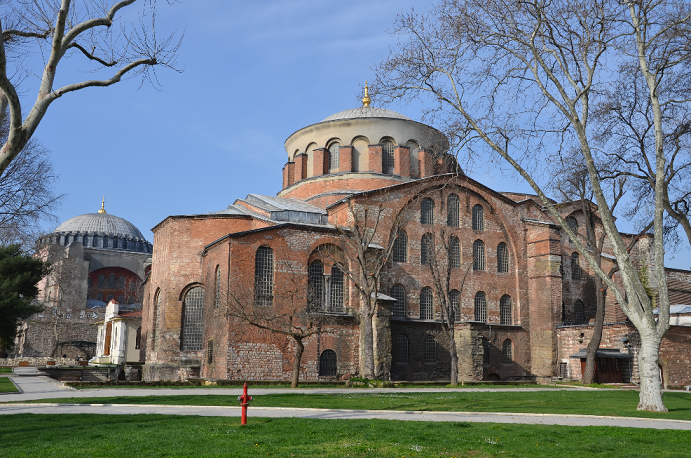

## Why am I in Tübingen?

### Revise thesis for publication

- Update literature
- Add sources

### Expand coverage

- Romanness and Christianness
- Romanness and gender

[figure not shown]

*Acts of the Quinsext Council (AD 692), British Library ADD MS 17474 fol. 216r*

### **Chapter: Roman = Christian**

**Constantinople**

- ‘Orthodoxy’ of the Imperial Church

**Levant**

- Schism over Chalcedon

**Italy**

- Attempted monopolisation of the label ‘Roman’

## Christianness in Constantinople

**Monothelitism**

- 638 - 681, 712 - 715

**Iconoclasm**

- *circa* 730 - 787, 814 - 843

**Historical embarassment?**

[figure not shown]

*Miniature from the Chludov Psalter,* circa *c9, depicting ‘eikonomachoi’*

## Christianness the Levant

### Miaphysites

- Chalcedonians = Romans = Greeks

### Chalcedonians

- Political subjects of the Caliphate, potential for ERE reconquest

### Influence of ‘eastern source’

## Christianness in Italy

### Empire-Romanness

- *res publica Romanorum*
- Romagna / Lombardia

### City-Romanness

- ‘natural’ identity
- synecdoche: leadership, policy

### Problematic regions

- Sicily, Apulia and Calabria
- Dalmatia, Africa

[figure not shown]

*Commemorating the brief autocephaly of Ravenna under Constans II*

## Discussion: Christians and barbarians

### Rhetorical confrontations

- Bulgarians
- *Dhimmi* communities
- Charlemagne

### Identity as a function of what-it-is-not

- If Roman = Orthodox, then Heretic = Barbarian

## Chapter: Gendered Romanness

### Interaction between layers of identity

**Existing: social roles available for women**

- Domesticity
- Asceticism

**Expand**

- legal status and protections?

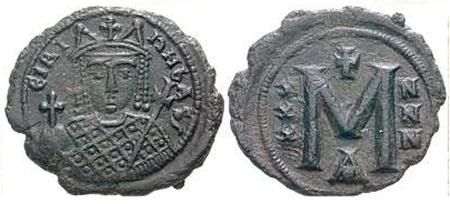

*Eirene: an exemplar of Orthodoxy, less so of motherly love*

## Goals in Tübingen: Summary

### Revise and update thesis

### Chapter: Romans = Christians

### Chapter: Roman women